# PRÁCTICA 3A: REPORTE ESCRITO. EXPERIMENTOS Y ANÁLISIS DE ALGORITMOS DE ORDENAMIENTO.

PROFESOR: DR. ERIC SADIT TÉLLEZ AVILA

ESTUDIANTE: EDGAR SANTIAGO GONZALEZ MARTINEZ

# Introducción

Esta práctica comparamos cinco algoritmos de ordenamiento (**Bubble Sort**, **Quicksort**, **Heapsort**, **Mergesort** y **Skip List Sort**) sobre los archivos `p016`, `p032`, `p064`, `p128`, `p256` y `p512`, con el objetivo de contrastar la teoría con observaciones experimentales en datos reales. Los detalles de cada método se presentan más adelante.

Para cada algoritmo se registran tres métricas: número de **comparaciones**, **movimientos** y **tiempo de ejecución**. Estas medidas permiten evaluar no solo la complejidad asintótica, sino también las **constantes ocultas** y el **impacto práctico**.

Bajo el modelo de ordenamiento por comparación, todo algoritmo requiere al menos $\Omega(n \log n)$ comparaciones, pues ordenar $n$ elementos implica distinguir entre $n!$ permutaciones. Por la aproximación de Stirling, $\log_2(n!) \in \Theta(n \log n)$.

# Conexión de Google Drive con Google Colab

Como primer procedimiento, se conecta Google Drive con Google Colab para poder acceder a los archivos almacenados en la nube.

La instrucción `from google.colab import drive` permite importar el módulo `drive`, el cual posibilita que Colab interactúe con Google Drive. El comando `drive.mount('/content/drive')` monta Google Drive en la carpeta `/content/drive`. Al ejecutarlo, Colab solicitará un permiso de acceso. Una vez concedido, los archivos estarán disponibles para lectura y escritura dentro del notebook.

```python
# Cargar Google Drive
from google.colab import drive
drive.mount('/content/drive')
```

# Extracción de archivos desde Google Drive

En esta parte se extraen los identificadores de los archivos almacenado en Google Drive y se convierten en un **arreglo de NumPy** listo para los algoritmos de ordenamiento. Se define la **ruta** del JSON (`path`) y la **clave** `KEY = "reunion"` que, si el archivo está estructurado como diccionario, indica dónde está la lista de IDs.

El archivo se abre con **codificación UTF-8** y se **parsea** con `json.load`, obteniendo un objeto de Python. A partir de ello se construye archivos con `np.asarray`.

El mismo procedimiento se realiza para todos los archivos (`p=016`, `p=032`, `p=064`, `p=128`, `p=256`, `p=512`), cambiando únicamente la ruta del archivo y generando los arreglos correspondientes.

```python
# Extraer los datos del archivo p016
path = "/content/drive/MyDrive/MCDI/3A_AdA/listas-posteo-con-perturbaciones/listas-posteo-con-perturbaciones-p=016.json"
KEY = "reunion"  # la clave que contiene la lista en tu JSON
with open(path, encoding="utf-8") as f:
    d = json.load(f)
archive_016 = np.asarray(d[KEY] if isinstance(d, dict) else d, dtype=np.int64)

# Extraer los datos del archivo p032
path = "/content/drive/MyDrive/MCDI/3A_AdA/listas-posteo-con-perturbaciones/listas-posteo-con-perturbaciones-p=032.json"
KEY = "reunion"  # clave que contiene la lista en el JSON
with open(path, encoding="utf-8") as f:
    d = json.load(f)
archive_032 = np.asarray(d[KEY] if isinstance(d, dict) else d, dtype=np.int64)

# Extraer los datos del archivo p064
path = "/content/drive/MyDrive/MCDI/3A_AdA/listas-posteo-con-perturbaciones/listas-posteo-con-perturbaciones-p=064.json"
KEY = "reunion"  # clave que contiene la lista en el JSON
with open(path, encoding="utf-8") as f:
    d = json.load(f)
archive_064 = np.asarray(d[KEY] if isinstance(d, dict) else d, dtype=np.int64)

# Extraer los datos del archivo p128
path = "/content/drive/MyDrive/MCDI/3A_AdA/listas-posteo-con-perturbaciones/listas-posteo-con-perturbaciones-p=128.json"
KEY = "reunion"  # clave que contiene la lista en el JSON
with open(path, encoding="utf-8") as f:
    d = json.load(f)
archive_128 = np.asarray(d[KEY] if isinstance(d, dict) else d, dtype=np.int64)

# Extraer los datos del archivo p256
path = "/content/drive/MyDrive/MCDI/3A_AdA/listas-posteo-con-perturbaciones/listas-posteo-con-perturbaciones-p=256.json"
KEY = "reunion"  # clave que contiene la lista en el JSON
with open(path, encoding="utf-8") as f:
    d = json.load(f)
archive_256 = np.asarray(d[KEY] if isinstance(d, dict) else d, dtype=np.int64)

# Extraer los datos del archivo p512
path = "/content/drive/MyDrive/MCDI/3A_AdA/listas-posteo-con-perturbaciones/listas-posteo-con-perturbaciones-p=512.json"
KEY = "reunion"  # clave que contiene la lista en el JSON
with open(path, encoding="utf-8") as f:
    d = json.load(f)
archive_512 = np.asarray(d[KEY] if isinstance(d, dict) else d, dtype=np.int64)
```

# Impresión de los archivos

Este fragmento recorre una **lista de tuplas** que asocia cada **etiqueta de dataset** con su **arreglo** correspondiente. En cada iteración el bucle `for` **desempaqueta** la tupla en `label` y `var` (el `np.ndarray` asociado) y, a partir de ahí, **imprime** un rótulo con la etiqueta y una vista del arreglo, por ejemplo, los primeros 12 elementos).

```python
for label, var in [
    ("p=016", archive_016),
    ("p=032", archive_032),
    ("p=064", archive_064),
    ("p=128", archive_128),
    ("p=256", archive_256),
    ("p=512", archive_512),
]:
    print(f"Archivo {label}:", var[:12])
```

```
Archivo p=016: [260 275 294 296 314 317 341 384 457 529 616 630]
Archivo p=032: [260 275 294 296 314 317 341 384 457 529 616 630]
Archivo p=064: [  260   275   294   296   314   317   341  6773   457   529   616 37512]
Archivo p=128: [  260   275 25442   296   314   317 11580   384   457   529   616   630]
Archivo p=256: [  260 43024   294   296 17944   317 17991   384   457   529   616   630]
Archivo p=512: [  260   275   294   296   314 42610   341   384   457   529 15293   630]
```

```python
print(len(archive_016))
print(len(archive_032))
print(len(archive_064))
print(len(archive_128))
print(len(archive_256))
print(len(archive_512))
```

```
3080
3080
3080
3080
3080
3080
```

# Paqueterías usadas

Se importan: `time`, `random`, `json`, `numpy as np` y `pandas as pd`.

- **time** — Cronometraje con `perf_counter()` en funciones `*_count_timed`; produce `time_ms`.
- **random** — Aleatoriedad (con `seed`) para el pivote en `quicksort_count` y los niveles en `skiplist_sort_count_timed`.
- **json** — Carga de datasets `.json` con `json.load(...)` y acceso por `KEY` antes de ejecutar los algoritmos.
- **numpy (np)** — Interoperación con `np.ndarray` (convertir a lista y devolver `np.array` preservando `dtype`); verificación con `np.sort` y `np.array_equal`.
- **pandas (pd)** — Consolidación de métricas en un `DataFrame` para comparar `comparisons`, `swaps/writes` y `time_ms`.

```python
# Imports necesarios
import time
import random
import json
import numpy as np
import pandas as pd
```

# Algoritmos de ordenamiento

## Bubble sort

Tomado de **Cormen et al. (2022)**, este procedimiento mantiene la lógica clásica de Bubble Sort y se añade **mediciones**. Primero **copia** la entrada a una lista `a`. Inicializa contadores de **comparaciones** (`comps`) e **intercambios** (`swaps`) y arranca el cronómetro con `time.perf_counter()`. Recorre el arreglo con dos bucles anidados: en cada iteración del interno **incrementa** `comps` y, si encuentra un par desordenado (`a[j] > a[j+1]`), realiza el **swap** y aumenta `swaps`. Al finalizar calcula el tiempo en **milisegundos** (`ms`) y **devuelve** la versión ordenada como `np.array`, junto con `comps`, `swaps` y `ms`. El comportamiento del algoritmo sigue siendo **estable**, opera *in-place* sobre la copia, usa espacio extra $O(1)$ y su costo temporal es $O(n^2)$; lo añadido es únicamente la **instrumentación** para comparar rendimientos.

```python
def bubble_sort_count(arr):
    a = arr.tolist() if isinstance(arr, np.ndarray) else list(arr)
    n = len(a)
    comps = swaps = 0
    t0 = time.perf_counter()
    for i in range(n - 1):
        for j in range(n - 1 - i):
            comps += 1
            if a[j] > a[j + 1]:
                a[j], a[j + 1] = a[j + 1], a[j]
                swaps += 1
    ms = (time.perf_counter() - t0) * 1000
    return np.array(a, dtype=arr.dtype if isinstance(arr, np.ndarray) else None), comps, swaps, ms
```

## Quick Sort

Tomado de **Cormen et al. (2022)**, se parte de la variante con **pivote aleatorio** y partición tipo **Lomuto**: el pivote se mueve a `A[high]`, se mantiene un índice `i` para los elementos **menores** que el pivote y se recorre `j` de `low` a `high-1`; cuando `A[j] < piv` se intercambia con `A[i]` y se avanza `i`. Al final el pivote se coloca en `A[i]` y se aplica recursión sobre los subarreglos izquierdo y derecho. En expectativa el tiempo es $O(n \log n)$; el peor caso es $O(n^2)$; el espacio extra es $O(1)$ (más el *stack*), y **no es estable**.

En esta práctica se utiliza `quicksort_count(arr, seed=183)`, que **añade instrumentación** sin cambiar la lógica: fija una **semilla** para reproducibilidad, trabaja sobre una **copia** de la entrada, **cuenta** comparaciones (`comps`) y **swaps** (`swaps`) —incluyendo el swap al mover el pivote y los intercambios con la zona “menor”— y **cronometra** con `time.perf_counter()` (milisegundos, `ms`). Devuelve el arreglo ordenado (preservando `dtype` si la entrada era `np.ndarray`) junto con `comps`, `swaps` y `ms`.

```python
def quicksort_count(arr, seed=183):
    random.seed(seed)
    a = arr.tolist() if isinstance(arr, np.ndarray) else list(arr)
    comps = swaps = 0

    def partition(lo, hi):
        nonlocal comps, swaps, a
        piv_idx = random.randint(lo, hi)
        a[piv_idx], a[hi] = a[hi], a[piv_idx]; swaps += 1
        piv = a[hi]
        i = lo
        for j in range(lo, hi):
            comps += 1
            if a[j] < piv:
                a[i], a[j] = a[j], a[i]; swaps += 1
                i += 1
        a[i], a[hi] = a[hi], a[i]; swaps += 1
        return i

    def qs(lo, hi):
        if lo < hi:
            p = partition(lo, hi)
            qs(lo, p - 1)
            qs(p + 1, hi)

    t0 = time.perf_counter()
    qs(0, len(a) - 1)
    ms = (time.perf_counter() - t0) * 1000
    return np.array(a, dtype=arr.dtype if isinstance(arr, np.ndarray) else None), comps, swaps, ms
```

## Herapsort

Tomado de la exposición estándar en **CLRS** (Cormen et al., 2022) y del trabajo original de **Williams** (1964), este Heapsort ordena **in-place** en dos fases: primero construye un **max-heap** con llamadas ascendentes a `_heapify` desde `i = n//2 - 1` hasta `0`, dejando el máximo en `A[0]`; después **extrae** el máximo iterativamente intercambiando `A[0]` con `A[end]`, reduciendo el tamaño lógico y restaurando la propiedad de heap con `_heapify(A, end, 0)`. La construcción cuesta $O(n)$; cada extracción $O(\log n)$, para un total $O(n \log n)$. Usa memoria $O(1)$, **no es estable** y la recursión de `_heapify` tiene profundidad $O(\log n)$.

La función `heapsort_count_timed(arr)` **añade instrumentación** sin cambiar la lógica: trabaja sobre una **copia** de la entrada, **cuenta** `comparisons` (una por cada evaluación `>` con los hijos en `heapify`) y **swaps** (tanto en `heapify` como en cada extracción `A[0] ↔ A[end]`), y **cronometra** el cuerpo del algoritmo con `time.perf_counter()` (milisegundos). Devuelve `(arreglo_ordenado, comparisons, swaps, time_ms)`; se conservan la complejidad $O(n \log n)$, el uso extra de espacio $O(1)$ y el carácter **no estable**.

```python
def heapsort_count_timed(arr):
    a = arr.tolist() if isinstance(arr, np.ndarray) else list(arr)
    n = len(a)
    comparisons = 0
    swaps = 0
    def heapify(n, i):
        nonlocal comparisons, swaps, a
        largest = i
        l = 2*i + 1
        r = 2*i + 2
        if l < n:
            comparisons += 1
            if a[l] > a[largest]:
                largest = l
        if r < n:
            comparisons += 1
            if a[r] > a[largest]:
                largest = r

        if largest != i:
            a[i], a[largest] = a[largest], a[i]
            swaps += 1
            heapify(n, largest)
    t0 = time.perf_counter()
    for i in range(n//2 - 1, -1, -1):
        heapify(n, i)
    for end in range(n - 1, 0, -1):
        a[0], a[end] = a[end], a[0]
        swaps += 1
        heapify(end, 0)
    ms = (time.perf_counter() - t0) * 1000
    return np.array(a, dtype=arr.dtype if isinstance(arr, np.ndarray) else None), comparisons, swaps, ms
```

## Mergesort

Basado en la presentación estándar (von Neumann, 1945; CLRS; Knuth), **Merge Sort** ordena por **divide y vencerás**: divide en mitades y luego **fusiona** en un paso lineal usando un **búfer auxiliar**. Es **estable**, cuesta $O(n \log n)$ en promedio/peor caso y requiere $O(n)$ de memoria adicional.

En esta práctica se usa `mergesort_count_timed(A)`, que **añade instrumentación** sin cambiar la lógica: **cuenta** `comparisons` durante la fusión (cada comparación `aux[i]` vs `aux[j]`), **cuenta** `writes` por cada escritura en la salida `a[k]` (se reporta como “swaps” para comparabilidad) y **cronometra** con `time.perf_counter()` (milisegundos). Devuelve `(arreglo_ordenado, comparisons, writes, time_ms)` y preserva el `dtype` si la entrada era `np.ndarray`.

```python
def mergesort_count_timed(A):
    a = A.tolist() if isinstance(A, np.ndarray) else list(A)
    n = len(a)
    aux = [None] * n
    comparisons = 0
    writes = 0
    def sort(lo, hi):
        nonlocal comparisons, writes, a, aux
        if lo >= hi:
            return
        mid = (lo + hi) // 2
        sort(lo, mid)
        sort(mid + 1, hi)
        # conteo
        aux[lo:hi+1] = a[lo:hi+1]
        i, j, k = lo, mid + 1, lo
        while i <= mid and j <= hi:
            comparisons += 1
            if aux[i] <= aux[j]:
                a[k] = aux[i]; i += 1
            else:
                a[k] = aux[j]; j += 1
            writes += 1
            k += 1
        while i <= mid:
            a[k] = aux[i]; i += 1; k += 1
            writes += 1
        while j <= hi:
            a[k] = aux[j]; j += 1; k += 1
            writes += 1
    t0 = time.perf_counter()
    sort(0, n - 1)
    ms = (time.perf_counter() - t0) * 1000
    return np.array(a, dtype=A.dtype if isinstance(A, np.ndarray) else None), comparisons, writes, ms
```

## Skip list

Basado en **Pugh (1990)** y exposiciones modernas, este método ordena insertando cada elemento en una **Skip List** y luego recorriendo el **nivel 0** para emitirlos en orden. La altura esperada es $O(\log n)$, cada inserción cuesta $O(\log n)$ en expectativa y el total resulta $O(n \log n)$ con espacio $\Theta(n)$. Al usar `<=` en la búsqueda, el resultado es **estable**.

En esta práctica se emplea `skiplist_sort_count_timed(A, p=0.5, max_level=32, seed=162)`, que **añade instrumentación** sin cambiar la lógica: fija una **semilla** (`seed`) para reproducibilidad, **copia** la entrada, y contabiliza **comparaciones** (`comparisons`) al descender por niveles comparando `x.next[i].key` con la clave, además de **escrituras** (`writes`) al **re-enlazar** punteros (dos por nivel). Se **cronometra** todo el proceso con `time.perf_counter()` (milisegundos, `time_ms`). Devuelve el arreglo ordenado (preservando `dtype` si la entrada era `np.ndarray`) junto con `comparisons`, `writes` y `time_ms`. El comportamiento esperado $O(n \log n)$ y la **estabilidad** se mantiene.

```python
def skiplist_sort_count_timed(A, p=0.5, max_level=32, seed=162):
    rng = random.Random(seed)
    def random_level():
        lvl = 0
        while rng.random() < p and lvl < max_level:
            lvl += 1
        return lvl

    class _SkipNode:
        __slots__ = ("key", "next")
        def __init__(self, key, level):
            self.key = key
            self.next = [None] * (level + 1)
    head = _SkipNode(None, max_level)
    level = 0
    a = A.tolist() if isinstance(A, np.ndarray) else list(A)
    comparisons = 0
    writes = 0

    t0 = time.perf_counter()

    for key in a:
        update = [None] * (max_level + 1)
        x = head
        for i in range(level, -1, -1):
            while x.next[i] is not None:
                comparisons += 1
                if x.next[i].key <= key:
                    x = x.next[i]
                else:
                    break
            update[i] = x

        lvl = random_level()
        if lvl > level:
            for i in range(level + 1, lvl + 1):
                update[i] = head
            level = lvl

        node = _SkipNode(key, lvl)
        for i in range(lvl + 1):
            node.next[i] = update[i].next[i]; writes += 1
            update[i].next[i] = node;          writes += 1
    out = []
    x = head.next[0]
    while x is not None:
        out.append(x.key)
        x = x.next[0]
    ms = (time.perf_counter() - t0) * 1000
    return np.array(out, dtype=A.dtype if isinstance(A, np.ndarray) else None), comparisons, writes, ms
```

# Evaluación de algoritmos con el Archivo p=016

Este bloque se ejecuta las evaluaciones. Primero fija la entrada `A` como `archive_016` y prepara una lista `rows` para acumular las métricas. Define una **batería de algoritmos** como pares `(nombre, función)`; en el caso de *Skip List* usa una `lambda` para fijar la semilla y asegurar **reproducibilidad**. En el bucle, cada `fn(A)` devuelve la salida ordenada (`out`) y las métricas (`comps`, `swaps_or_writes`, `ms`). Se valida la **corrección** con `assert np.array_equal(out, np.sort(A))`, comparando contra la referencia de NumPy. Luego se agrega un renglón a `rows` con: el dataset (`"p016"`), el nombre del algoritmo, el tamaño `n`, el número de **comparaciones**, los **movimientos** y el **tiempo** en milisegundos. Finalmente, `pd.DataFrame(rows)` construye la tabla `df` que resume los resultados de todos los algoritmos sobre el mismo arreglo `A`.

```python
A = archive_016
rows = []
for name, fn in [
    ("bubblesort", bubble_sort_count),
    ("quicksort",  quicksort_count),
    ("heapsort",   heapsort_count_timed),
    ("mergesort",  mergesort_count_timed),
    ("skiplist",   lambda X: skiplist_sort_count_timed(X, seed=123)),
]:
    out, comps, swaps_or_writes, ms = fn(A)
    assert np.array_equal(out, np.sort(A)), f"{name} no coincide con np.sort"
    rows.append({
        "dataset": "p016",
        "algo": name,
        "n": len(A),
        "comparisons": comps,
        "swaps": swaps_or_writes,
        "time_ms": ms
    })
df = pd.DataFrame(rows)
df
```

|  | dataset | algo | n | comparisons | swaps | time_ms |
| --- | --- | --- | --- | --- | --- | --- |
| 0 | p016 | bubblesort | 3080 | 4741660 | 25392 | 794.521485 |
| 1 | p016 | quicksort | 3080 | 41893 | 22193 | 14.305161 |
| 2 | p016 | heapsort | 3080 | 64787 | 35252 | 24.546448 |
| 3 | p016 | mergesort | 3080 | 23867 | 35944 | 15.373446 |
| 4 | p016 | skiplist | 3080 | 47219 | 12168 | 23.731101 |

En `p016` (n = 3080), **Bubble Sort** realiza **4,741,660** comparaciones, **25,392** *swaps* y tarda **≈0.795 s**, confirmando su costo cuadrático. Entre los métodos $O(n \log n)$, **Quicksort** es el más rápido con **≈14.3 ms** y **41,893** comparaciones, seguido de **Mergesort** con **≈15.4 ms**, **23,867** comparaciones y **35,944** *writes* (reportados en “swaps”). **Heapsort** queda detrás con **≈24.5 ms**, **64,787** comparaciones y **35,252** *swaps*, y **Skip List Sort** con **≈23.7 ms**, **47,219** comparaciones y **12,168** *writes*. En conjunto, los $O(n \log n)$ dominan; las diferencias se explican por constantes y modelo de memoria. El **gráfico inferior** reproduce estos mismos valores de la tabla.

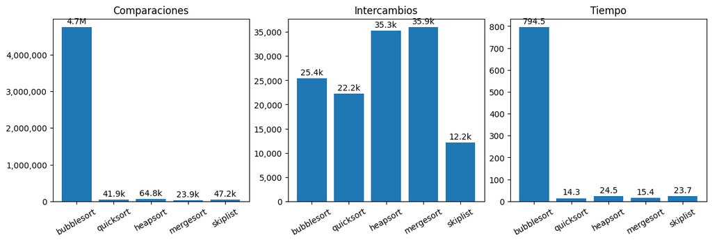

```python
import matplotlib.pyplot as plt
from matplotlib.ticker import FuncFormatter
import numpy as np

order = ['bubblesort', 'quicksort', 'heapsort', 'mergesort', 'skiplist']
agg = (df.groupby('algo', as_index=False)
         .agg(comparisons=('comparisons','mean'),
              swaps=('swaps','mean'),
              time_ms=('time_ms','mean')))
agg['algo'] = pd.Categorical(agg['algo'], categories=order, ordered=True)
agg = agg.sort_values('algo')

def abbr(x):
    if x >= 1_000_000:
        return f'{x/1_000_000:.1f}M'
    if x >= 1_000:
        return f'{x/1_000:.1f}k'
    return f'{x:.1f}'

fig, axes = plt.subplots(1, 3, figsize=(12, 4), constrained_layout=True)

# Comparaciones
bars = axes[0].bar(agg['algo'], agg['comparisons'])
axes[0].set_title('Comparaciones')
axes[0].yaxis.set_major_formatter(FuncFormatter(lambda v, _: f'{int(v):,}'))
axes[0].tick_params(axis='x', rotation=30)
axes[0].bar_label(bars, labels=[abbr(v) for v in agg['comparisons']], padding=2)
# Intercambios
bars = axes[1].bar(agg['algo'], agg['swaps'])
axes[1].set_title('Intercambios')
axes[1].yaxis.set_major_formatter(FuncFormatter(lambda v, _: f'{int(v):,}'))
axes[1].tick_params(axis='x', rotation=30)
axes[1].bar_label(bars, labels=[abbr(v) for v in agg['swaps']], padding=2)
# Tiempo en ms
bars = axes[2].bar(agg['algo'], agg['time_ms'])
axes[2].set_title('Tiempo')
axes[2].tick_params(axis='x', rotation=30)
axes[2].bar_label(bars, labels=[abbr(v) for v in agg['time_ms']], padding=2)

plt.show()
```

# Evaluación de algoritmos con el Archivo p=032

Para el archivo `p=032` (n = 3080), **Bubble Sort** realiza **4,741,660** comparaciones, **80,866** *swaps* y tarda **≈456.30 ms**. Entre los métodos $O(n \log n)$, **Quicksort** es el más rápido (**≈6.72 ms**; **39,005** comparaciones), seguido de **Mergesort** (**≈7.84 ms**; **24,791** comparaciones y **35,944** *writes*). **Heapsort** queda detrás (**≈12.87 ms**; **64,715** comparaciones) y **Skip List Sort** (**≈13.17 ms**; **53,135** comparaciones y **12,168** *writes*) se ve penalizado por el *overhead* de punteros. En conjunto, dominan los $O(n \log n)$; las diferencias se explican por constantes y modelo de memoria. El **gráfico inferior** reproduce estos mismos valores de la tabla.

```python
A = archive_032
rows = []
for name, fn in [
    ("bubblesort", bubble_sort_count),
    ("quicksort",  quicksort_count),
    ("heapsort",   heapsort_count_timed),
    ("mergesort",  mergesort_count_timed),
    ("skiplist",   lambda X: skiplist_sort_count_timed(X, seed=123)),
]:
    out, comps, swaps_or_writes, ms = fn(A)
    assert np.array_equal(out, np.sort(A)), f"{name} no coincide con np.sort"
    rows.append({
        "dataset": "p032",
        "algo": name,
        "n": len(A),
        "comparisons": comps,
        "swaps": swaps_or_writes,
        "time_ms": ms
    })
df = pd.DataFrame(rows)
df
```

|  | dataset | algo | n | comparisons | swaps | time_ms |
| --- | --- | --- | --- | --- | --- | --- |
| 0 | p032 | bubblesort | 3080 | 4741660 | 80866 | 456.298937 |
| 1 | p032 | quicksort | 3080 | 39005 | 20983 | 6.721965 |
| 2 | p032 | heapsort | 3080 | 64715 | 35202 | 12.872209 |
| 3 | p032 | mergesort | 3080 | 24791 | 35944 | 7.839713 |
| 4 | p032 | skiplist | 3080 | 53135 | 12168 | 13.170960 |

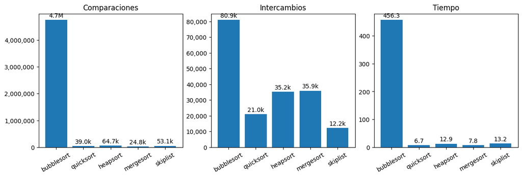

```python
order = ['bubblesort', 'quicksort', 'heapsort', 'mergesort', 'skiplist']
agg = (df.groupby('algo', as_index=False)
         .agg(comparisons=('comparisons','mean'),
              swaps=('swaps','mean'),
              time_ms=('time_ms','mean')))
agg['algo'] = pd.Categorical(agg['algo'], categories=order, ordered=True)
agg = agg.sort_values('algo')

def abbr(x):
    if x >= 1_000_000:
        return f'{x/1_000_000:.1f}M'
    if x >= 1_000:
        return f'{x/1_000:.1f}k'
    return f'{x:.1f}'

fig, axes = plt.subplots(1, 3, figsize=(12, 4), constrained_layout=True)

# Comparaciones
bars = axes[0].bar(agg['algo'], agg['comparisons'])
axes[0].set_title('Comparaciones')
axes[0].yaxis.set_major_formatter(FuncFormatter(lambda v, _: f'{int(v):,}'))
axes[0].tick_params(axis='x', rotation=30)
axes[0].bar_label(bars, labels=[abbr(v) for v in agg['comparisons']], padding=2)
# Intercambios
bars = axes[1].bar(agg['algo'], agg['swaps'])
axes[1].set_title('Intercambios')
axes[1].yaxis.set_major_formatter(FuncFormatter(lambda v, _: f'{int(v):,}'))
axes[1].tick_params(axis='x', rotation=30)
axes[1].bar_label(bars, labels=[abbr(v) for v in agg['swaps']], padding=2)
# Tiempo en ms
bars = axes[2].bar(agg['algo'], agg['time_ms'])
axes[2].set_title('Tiempo')
axes[2].tick_params(axis='x', rotation=30)
axes[2].bar_label(bars, labels=[abbr(v) for v in agg['time_ms']], padding=2)

plt.show()
```

# Evaluación de algoritmos con el Archivo p=064

Para el archivo `p=064` (n = 3080), **Bubble Sort** realiza **4,741,660** comparaciones, **124,486** *swaps* y tarda **≈465.9 ms**, manteniéndose como el más lento. Entre los $O(n \log n)$, **Quicksort** es el más rápido (**≈10.85 ms**; **40,073** comparaciones), seguido de **Mergesort** (**≈13.62 ms**; **26,917** comparaciones y **35,944** *writes*) y **Skip List Sort** (**≈14.58 ms**; **51,285** comparaciones y **12,168** *writes*). **Heapsort** queda detrás (**≈23.27 ms**; **64,654** comparaciones y **35,160** *swaps*). El **gráfico inferior** reproduce estos mismos valores de la tabla para comparación visual.

```python
A = archive_064
rows = []
for name, fn in [
    ("bubblesort", bubble_sort_count),
    ("quicksort",  quicksort_count),
    ("heapsort",   heapsort_count_timed),
    ("mergesort",  mergesort_count_timed),
    ("skiplist",   lambda X: skiplist_sort_count_timed(X, seed=123)),
]:
    out, comps, swaps_or_writes, ms = fn(A)
    assert np.array_equal(out, np.sort(A)), f"{name} no coincide con np.sort"
    rows.append({
        "dataset": "p064",
        "algo": name,
        "n": len(A),
        "comparisons": comps,
        "swaps": swaps_or_writes,
        "time_ms": ms
    })

df = pd.DataFrame(rows)
df
```

|  | dataset | algo | n | comparisons | swaps | time_ms |
| --- | --- | --- | --- | --- | --- | --- |
| 0 | p064 | bubblesort | 3080 | 4741660 | 124486 | 465.892737 |
| 1 | p064 | quicksort | 3080 | 40073 | 20819 | 10.847561 |
| 2 | p064 | heapsort | 3080 | 64654 | 35160 | 23.265947 |
| 3 | p064 | mergesort | 3080 | 26917 | 35944 | 13.616630 |
| 4 | p064 | skiplist | 3080 | 51285 | 12168 | 14.575142 |

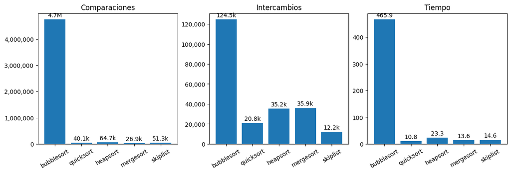

```python
order = ['bubblesort', 'quicksort', 'heapsort', 'mergesort', 'skiplist']
agg = (df.groupby('algo', as_index=False)
         .agg(comparisons=('comparisons','mean'),
              swaps=('swaps','mean'),
              time_ms=('time_ms','mean')))
agg['algo'] = pd.Categorical(agg['algo'], categories=order, ordered=True)
agg = agg.sort_values('algo')

def abbr(x):
    if x >= 1_000_000:
        return f'{x/1_000_000:.1f}M'
    if x >= 1_000:
        return f'{x/1_000:.1f}k'
    return f'{x:.1f}'

fig, axes = plt.subplots(1, 3, figsize=(12, 4), constrained_layout=True)

# Comparaciones
bars = axes[0].bar(agg['algo'], agg['comparisons'])
axes[0].set_title('Comparaciones')
axes[0].yaxis.set_major_formatter(FuncFormatter(lambda v, _: f'{int(v):,}'))
axes[0].tick_params(axis='x', rotation=30)
axes[0].bar_label(bars, labels=[abbr(v) for v in agg['comparisons']], padding=2)
# Intercambios
bars = axes[1].bar(agg['algo'], agg['swaps'])
axes[1].set_title('Intercambios')
axes[1].yaxis.set_major_formatter(FuncFormatter(lambda v, _: f'{int(v):,}'))
axes[1].tick_params(axis='x', rotation=30)
axes[1].bar_label(bars, labels=[abbr(v) for v in agg['swaps']], padding=2)
# Tiempo en ms
bars = axes[2].bar(agg['algo'], agg['time_ms'])
axes[2].set_title('Tiempo')
axes[2].tick_params(axis='x', rotation=30)
axes[2].bar_label(bars, labels=[abbr(v) for v in agg['time_ms']], padding=2)

plt.show()
```

# Evaluación de algoritmos con el Archivo p=128

Para el archivo `p=128` (n = 3080), **Bubble Sort** realiza **4,741,660** comparaciones, **260,888** *swaps* y tarda **≈485.85 ms**, confirmando su desventaja práctica frente a los $O(n \log n)$. Entre estos, **Quicksort** es el más rápido (**≈7.35 ms**; **40,527** comparaciones), seguido de **Mergesort** (**≈8.79 ms**; **28,882** comparaciones y **35,944** *writes*). **Heapsort** queda detrás (**≈22.44 ms**; **64,536** comparaciones) y **Skip List Sort** se sitúa en medio (**≈13.80 ms**; **60,073** comparaciones y **12,168** *writes*). El **gráfico inferior** reproduce estos mismos valores para comparación visual.

```python
A = archive_128
rows = []
for name, fn in [
    ("bubblesort", bubble_sort_count),
    ("quicksort",  quicksort_count),
    ("heapsort",   heapsort_count_timed),
    ("mergesort",  mergesort_count_timed),
    ("skiplist",   lambda X: skiplist_sort_count_timed(X, seed=123)),
]:
    out, comps, swaps_or_writes, ms = fn(A)
    assert np.array_equal(out, np.sort(A)), f"{name} no coincide con np.sort"
    rows.append({
        "dataset": "128",
        "algo": name,
        "n": len(A),
        "comparisons": comps,
        "swaps": swaps_or_writes,
        "time_ms": ms
    })
df = pd.DataFrame(rows)
df
```

|  | dataset | algo | n | comparisons | swaps | time_ms |
| --- | --- | --- | --- | --- | --- | --- |
| 0 | 128 | bubblesort | 3080 | 4741660 | 260888 | 485.852285 |
| 1 | 128 | quicksort | 3080 | 40527 | 21263 | 7.354733 |
| 2 | 128 | heapsort | 3080 | 64536 | 35040 | 22.439370 |
| 3 | 128 | mergesort | 3080 | 28882 | 35944 | 8.787886 |
| 4 | 128 | skiplist | 3080 | 60073 | 12168 | 13.803144 |

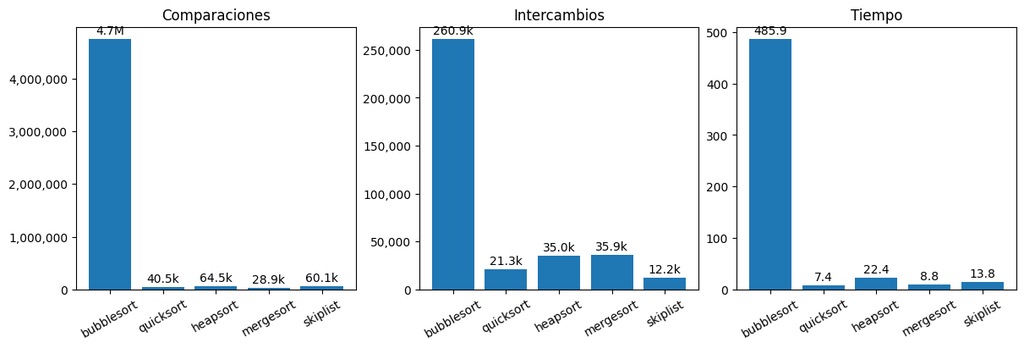

```python
order = ['bubblesort', 'quicksort', 'heapsort', 'mergesort', 'skiplist']
agg = (df.groupby('algo', as_index=False)
         .agg(comparisons=('comparisons','mean'),
              swaps=('swaps','mean'),
              time_ms=('time_ms','mean')))
agg['algo'] = pd.Categorical(agg['algo'], categories=order, ordered=True)
agg = agg.sort_values('algo')

def abbr(x):
    if x >= 1_000_000:
        return f'{x/1_000_000:.1f}M'
    if x >= 1_000:
        return f'{x/1_000:.1f}k'
    return f'{x:.1f}'

fig, axes = plt.subplots(1, 3, figsize=(12, 4), constrained_layout=True)

# Comparaciones
bars = axes[0].bar(agg['algo'], agg['comparisons'])
axes[0].set_title('Comparaciones')
axes[0].yaxis.set_major_formatter(FuncFormatter(lambda v, _: f'{int(v):,}'))
axes[0].tick_params(axis='x', rotation=30)
axes[0].bar_label(bars, labels=[abbr(v) for v in agg['comparisons']], padding=2)
# Intercambios
bars = axes[1].bar(agg['algo'], agg['swaps'])
axes[1].set_title('Intercambios')
axes[1].yaxis.set_major_formatter(FuncFormatter(lambda v, _: f'{int(v):,}'))
axes[1].tick_params(axis='x', rotation=30)
axes[1].bar_label(bars, labels=[abbr(v) for v in agg['swaps']], padding=2)
# Tiempo en ms
bars = axes[2].bar(agg['algo'], agg['time_ms'])
axes[2].set_title('Tiempo')
axes[2].tick_params(axis='x', rotation=30)
axes[2].bar_label(bars, labels=[abbr(v) for v in agg['time_ms']], padding=2)

plt.show()
```

# Evaluación de algoritmos con el Archivo p=256

Para el archivo `p=256` (n = 3080), **Bubble Sort** realiza **4,741,660** comparaciones, **452,612** *swaps* y tarda **≈501.74 ms**, quedando muy por detrás de los $O(n \log n)$. Entre estos, **Quicksort** es el más rápido (**≈7.26 ms**; **40,946** comparaciones), seguido de **Mergesort** (**≈8.36 ms**; **29,803** comparaciones y **35,944** *writes*). **Heapsort** viene después (**≈12.64 ms**; **64,315** comparaciones) y **Skip List Sort** cierra el grupo (**≈14.22 ms**; **54,320** comparaciones y **12,168** *writes*).

```python
A = archive_256
rows = []
for name, fn in [
    ("bubblesort", bubble_sort_count),
    ("quicksort",  quicksort_count),
    ("heapsort",   heapsort_count_timed),
    ("mergesort",  mergesort_count_timed),
    ("skiplist",   lambda X: skiplist_sort_count_timed(X, seed=123)),
]:
    out, comps, swaps_or_writes, ms = fn(A)
    assert np.array_equal(out, np.sort(A)), f"{name} no coincide con np.sort"
    rows.append({
        "dataset": "256",
        "algo": name,
        "n": len(A),
        "comparisons": comps,
        "swaps": swaps_or_writes,
        "time_ms": ms
    })
df = pd.DataFrame(rows)
df
```

|  | dataset | algo | n | comparisons | swaps | time_ms |
| --- | --- | --- | --- | --- | --- | --- |
| 0 | 256 | bubblesort | 3080 | 4741660 | 452612 | 501.743030 |
| 1 | 256 | quicksort | 3080 | 40946 | 22140 | 7.256318 |
| 2 | 256 | heapsort | 3080 | 64315 | 34920 | 12.643787 |
| 3 | 256 | mergesort | 3080 | 29803 | 35944 | 8.356604 |
| 4 | 256 | skiplist | 3080 | 54320 | 12168 | 14.218479 |

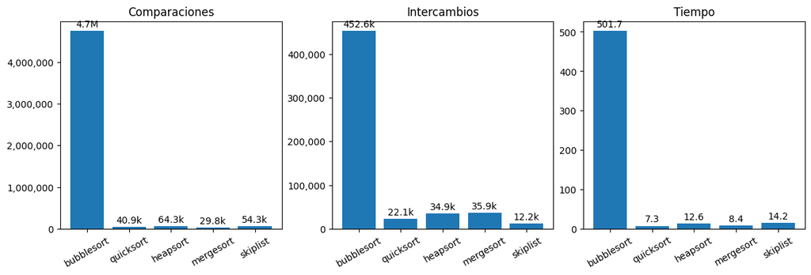

```python
order = ['bubblesort', 'quicksort', 'heapsort', 'mergesort', 'skiplist']
agg = (df.groupby('algo', as_index=False)
         .agg(comparisons=('comparisons','mean'),
              swaps=('swaps','mean'),
              time_ms=('time_ms','mean')))
agg['algo'] = pd.Categorical(agg['algo'], categories=order, ordered=True)
agg = agg.sort_values('algo')

def abbr(x):
    if x >= 1_000_000:
        return f'{x/1_000_000:.1f}M'
    if x >= 1_000:
        return f'{x/1_000:.1f}k'
    return f'{x:.1f}'

fig, axes = plt.subplots(1, 3, figsize=(12, 4), constrained_layout=True)

# Comparaciones
bars = axes[0].bar(agg['algo'], agg['comparisons'])
axes[0].set_title('Comparaciones')
axes[0].yaxis.set_major_formatter(FuncFormatter(lambda v, _: f'{int(v):,}'))
axes[0].tick_params(axis='x', rotation=30)
axes[0].bar_label(bars, labels=[abbr(v) for v in agg['comparisons']], padding=2)
# Intercambios
bars = axes[1].bar(agg['algo'], agg['swaps'])
axes[1].set_title('Intercambios')
axes[1].yaxis.set_major_formatter(FuncFormatter(lambda v, _: f'{int(v):,}'))
axes[1].tick_params(axis='x', rotation=30)
axes[1].bar_label(bars, labels=[abbr(v) for v in agg['swaps']], padding=2)
# Tiempo en ms
bars = axes[2].bar(agg['algo'], agg['time_ms'])
axes[2].set_title('Tiempo')
axes[2].tick_params(axis='x', rotation=30)
axes[2].bar_label(bars, labels=[abbr(v) for v in agg['time_ms']], padding=2)

plt.show()
```

# Evaluación de algoritmos con el Archivo p=512

Para el archivo `p=512` (n = 3080), **Bubble Sort** realiza **4,741,660** comparaciones, **796,239** *swaps* y tarda **≈550.29 ms**, confirmando su desventaja práctica. Entre los $O(n \log n)$, **Quicksort** es el más rápido (**≈8.04 ms**; **41,467** comparaciones), seguido muy de cerca por **Mergesort** (**≈8.48 ms**; **30,845** comparaciones y **35,944** *writes*). **Heapsort** queda después (**≈12.83 ms**; **63,936** comparaciones) y **Skip List Sort** cierra el grupo (**≈13.08 ms**; **60,772** comparaciones y **12,168** *writes*). En conjunto, los $O(n \log n)$ dominan; las diferencias responden a constantes y efectos de memoria.

```python
A = archive_512
rows = []
for name, fn in [
    ("bubblesort", bubble_sort_count),
    ("quicksort",  quicksort_count),
    ("heapsort",   heapsort_count_timed),
    ("mergesort",  mergesort_count_timed),
    ("skiplist",   lambda X: skiplist_sort_count_timed(X, seed=123)),
]:
    out, comps, swaps_or_writes, ms = fn(A)
    assert np.array_equal(out, np.sort(A)), f"{name} no coincide con np.sort"
    rows.append({
        "dataset": "512",
        "algo": name,
        "n": len(A),
        "comparisons": comps,
        "swaps": swaps_or_writes,
        "time_ms": ms
    })
df = pd.DataFrame(rows)
df
```

|  | dataset | algo | n | comparisons | swaps | time_ms |
| --- | --- | --- | --- | --- | --- | --- |
| 0 | 512 | bubblesort | 3080 | 4741660 | 796239 | 550.291931 |
| 1 | 512 | quicksort | 3080 | 41467 | 22721 | 8.036600 |
| 2 | 512 | heapsort | 3080 | 63936 | 34603 | 12.833832 |
| 3 | 512 | mergesort | 3080 | 30845 | 35944 | 8.477739 |
| 4 | 512 | skiplist | 3080 | 60772 | 12168 | 13.080908 |

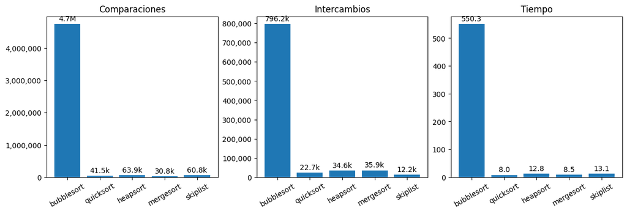

```python
order = ['bubblesort', 'quicksort', 'heapsort', 'mergesort', 'skiplist']
agg = (df.groupby('algo', as_index=False)
         .agg(comparisons=('comparisons','mean'),
              swaps=('swaps','mean'),
              time_ms=('time_ms','mean')))
agg['algo'] = pd.Categorical(agg['algo'], categories=order, ordered=True)
agg = agg.sort_values('algo')

def abbr(x):
    if x >= 1_000_000:
        return f'{x/1_000_000:.1f}M'
    if x >= 1_000:
        return f'{x/1_000:.1f}k'
    return f'{x:.1f}'

fig, axes = plt.subplots(1, 3, figsize=(12, 4), constrained_layout=True)

# Comparaciones
bars = axes[0].bar(agg['algo'], agg['comparisons'])
axes[0].set_title('Comparaciones')
axes[0].yaxis.set_major_formatter(FuncFormatter(lambda v, _: f'{int(v):,}'))
axes[0].tick_params(axis='x', rotation=30)
axes[0].bar_label(bars, labels=[abbr(v) for v in agg['comparisons']], padding=2)
# Intercambios
bars = axes[1].bar(agg['algo'], agg['swaps'])
axes[1].set_title('Intercambios')
axes[1].yaxis.set_major_formatter(FuncFormatter(lambda v, _: f'{int(v):,}'))
axes[1].tick_params(axis='x', rotation=30)
axes[1].bar_label(bars, labels=[abbr(v) for v in agg['swaps']], padding=2)
# Tiempo en ms
bars = axes[2].bar(agg['algo'], agg['time_ms'])
axes[2].set_title('Tiempo')
axes[2].tick_params(axis='x', rotation=30)
axes[2].bar_label(bars, labels=[abbr(v) for v in agg['time_ms']], padding=2)

plt.show()
```

# Conclusión

En todos los conjuntos, los resultados confirman la teoría: los métodos $O(n \log n)$ superan con claridad a **Bubble Sort** ($O(n^2)$). En promedio, **Quicksort** resulta el más rápido gracias a su localidad de memoria y ejecución *in-place* (aunque no es estable y su peor caso sigue siendo $O(n^2)$, mitigado con pivote aleatorio). **Mergesort** es igual de competitivo, realiza menos comparaciones y es **estable**, pero requiere **memoria $O(n)$** y más escrituras. **Heapsort** garantiza $O(n \log n)$ *in-place* y sin memoria extra, pero suele quedar detrás por mayor número de *swaps* y peor localidad; **Skip List Sort** mantiene el orden esperado $O(n \log n)$, aunque el *overhead* de punteros lo hace más lento que quick/merge.

# Referencias

Cormen, T. H., Leiserson, C. E., Rivest, R. L., & Stein, C. (2022). *Introduction to Algorithms* (4.ª ed.). MIT Press.

Knuth, D. E. (1998). *The Art of Computer Programming, Vol. 3: Sorting and Searching* (2.ª ed.). Addison–Wesley.

Pugh, W. (1990). Skip lists: A probabilistic alternative to balanced trees. *Communications of the ACM, 33*(6), 668–676.

Sadit. (s. f.). 4 Algoritmos de ordenamiento. En *Curso Introductorio al Análisis de Algoritmos con Julia*. Recuperado de https://sadit.github.io/ALGO-IR/cap4-ordenamiento.html

Wikipedia contributors. (s. f.). *Merge sort*. En *Wikipedia, The Free Encyclopedia*. Recuperado el 8 de octubre de 2025, de https://en.wikipedia.org/wiki/Merge_sort

Williams, J. W. J. (1964). Algorithm 232: Heapsort. *Communications of the ACM, 7*(6), 347–348.